# Boston Housing

Tristan-Mihai Radulescu, Hugo Ponthieu, Benoit Planche

# **Introduction**

This report analyzes the `BostonHousing` dataset, which contains information about housing in Boston. We will explore the relationships between several variables and the median home value (`medv`).

# **1. Loading Libraries and Data**

|  | crim | zn | indus | chas | nox | rm | age | dis | rad | tax | ptratio | b | lstat | medv |
| --- | --- | --- | --- | --- | --- | --- | --- | --- | --- | --- | --- | --- | --- | --- |
| 1 | 0.00632 | 18 | 2.31 | 0 | 0.538 | 6.575 | 65.2 | 4.0900 | 1 | 296 | 15.3 | 396.90 | 4.98 | 24.0 |
| 2 | 0.02731 | 0 | 7.07 | 0 | 0.469 | 6.421 | 78.9 | 4.9671 | 2 | 242 | 17.8 | 396.90 | 9.14 | 21.6 |
| 3 | 0.02729 | 0 | 7.07 | 0 | 0.469 | 7.185 | 61.1 | 4.9671 | 2 | 242 | 17.8 | 392.83 | 4.03 | 34.7 |
| 4 | 0.03237 | 0 | 2.18 | 0 | 0.458 | 6.998 | 45.8 | 6.0622 | 3 | 222 | 18.7 | 394.63 | 2.94 | 33.4 |
| 5 | 0.06905 | 0 | 2.18 | 0 | 0.458 | 7.147 | 54.2 | 6.0622 | 3 | 222 | 18.7 | 396.90 | 5.33 | 36.2 |
| 6 | 0.02985 | 0 | 2.18 | 0 | 0.458 | 6.430 | 58.7 | 6.0622 | 3 | 222 | 18.7 | 394.12 | 5.21 | 28.7 |

```
## 'data.frame':    506 obs. of  14 variables:
##  $ crim   : num  0.00632 0.02731 0.02729 0.03237 0.06905 ...
##  $ zn     : num  18 0 0 0 0 0 12.5 12.5 12.5 12.5 ...
##  $ indus  : num  2.31 7.07 7.07 2.18 2.18 2.18 7.87 7.87 7.87 7.87 ...
##  $ chas   : int  0 0 0 0 0 0 0 0 0 0 ...
##  $ nox    : num  0.538 0.469 0.469 0.458 0.458 0.458 0.524 0.524 0.524 0.524 ...
##  $ rm     : num  6.58 6.42 7.18 7 7.15 ...
##  $ age    : num  65.2 78.9 61.1 45.8 54.2 58.7 66.6 96.1 100 85.9 ...
##  $ dis    : num  4.09 4.97 4.97 6.06 6.06 ...
##  $ rad    : int  1 2 2 3 3 3 5 5 5 5 ...
##  $ tax    : int  296 242 242 222 222 222 311 311 311 311 ...
##  $ ptratio: num  15.3 17.8 17.8 18.7 18.7 18.7 15.2 15.2 15.2 15.2 ...
##  $ b      : num  397 397 393 395 397 ...
##  $ lstat  : num  4.98 9.14 4.03 2.94 5.33 ...
##  $ medv   : num  24 21.6 34.7 33.4 36.2 28.7 22.9 27.1 16.5 18.9 ...
```

# **2. Exploring Relationships Between Variables**

## **Scatterplot Matrix**

We use `pairs()` to observe relationships between multiple key variables.

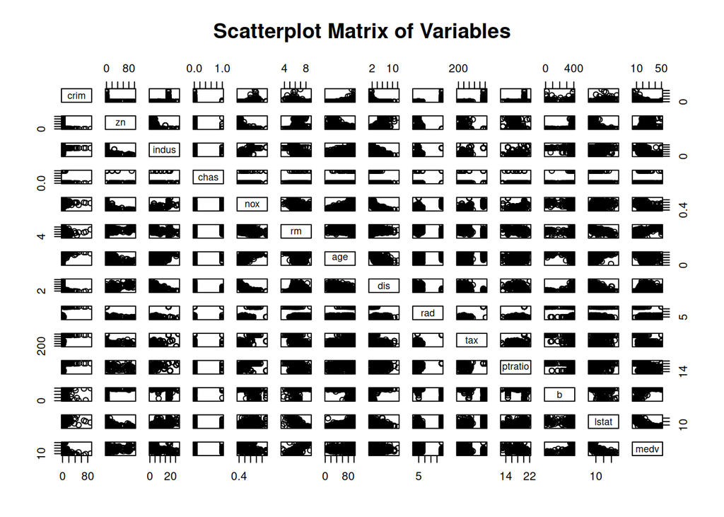

# **3. Relationship Between Number of Rooms and House Prices**

We analyze how the average number of rooms (`rm`) influences home values (`medv`).

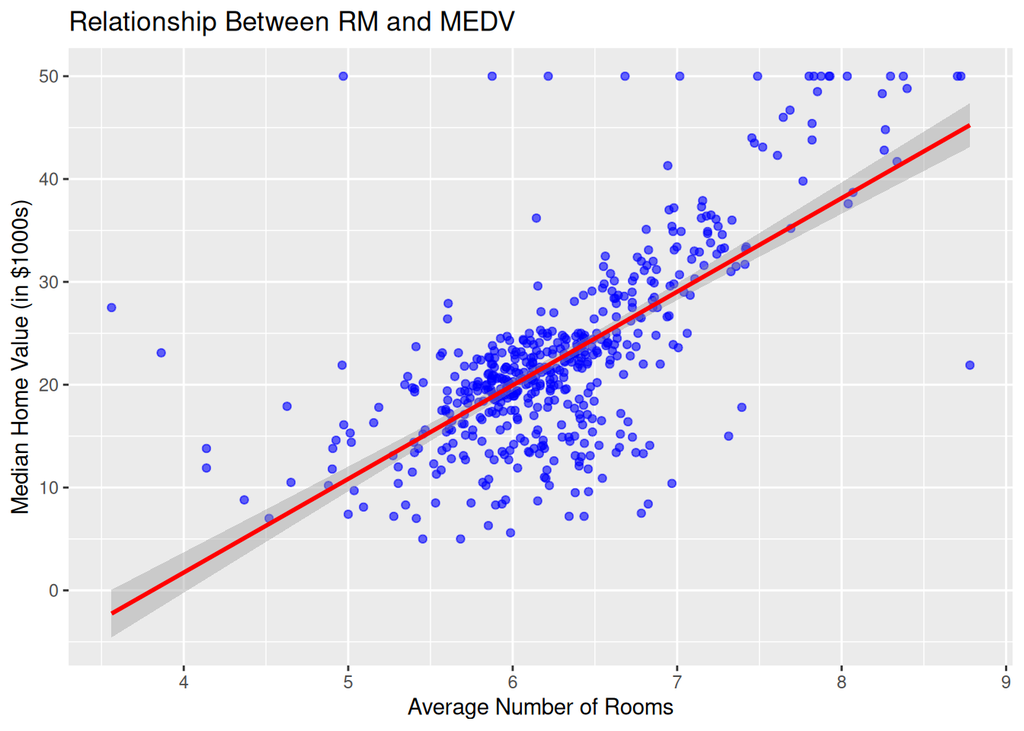

**Observation**: There is a **strong positive relationship** between `rm` and `medv`. The more rooms a house has, the higher its price.

# **4. Influence of Proximity to the River**

We examine whether being close to the Charles River (`chas`) affects home prices.

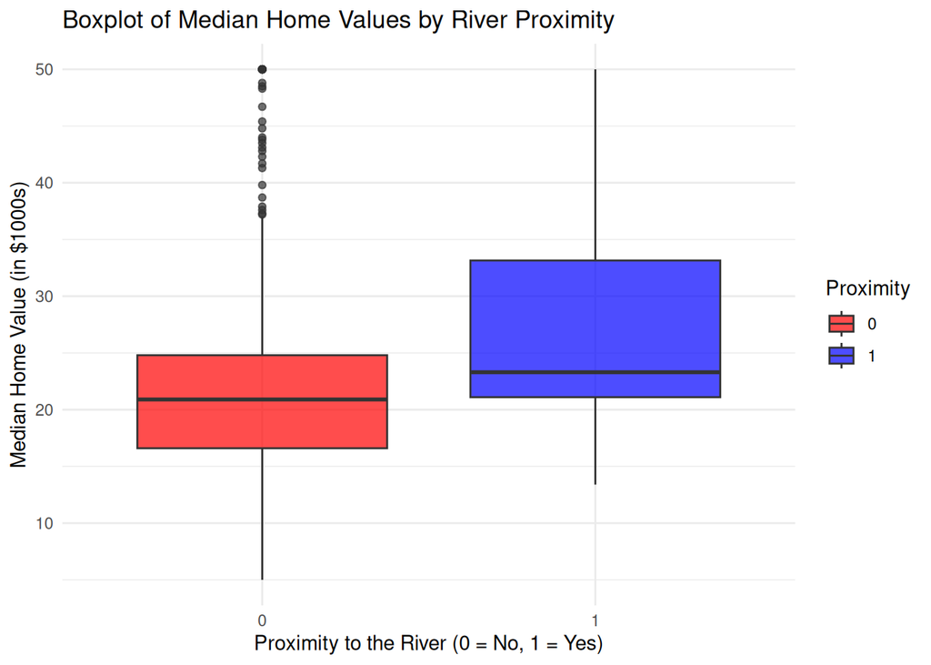

**Observation**: Proximity to the river **seems to have a slight impact** on home prices, but the distribution remains fairly similar.

# **5. Distribution of Key Variables**

We analyze the distribution of home prices (`medv`).

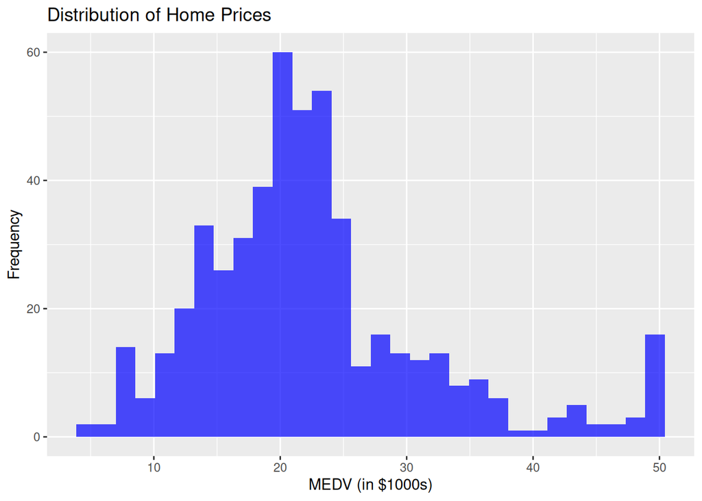

# **6. Correlations Between Variables**

We compute the correlation matrix and display values associated with `medv`.

```r
# Compute correlation matrix
cor_matrix <- cor(BostonHousing)

# Display correlations with MEDV
cor_matrix["medv", ]
```

```
##       crim         zn      indus       chas        nox         rm        age
## -0.3883046  0.3604453 -0.4837252  0.1752602 -0.4273208  0.6953599 -0.3769546
##        dis        rad        tax    ptratio          b      lstat       medv
##  0.2499287 -0.3816262 -0.4685359 -0.5077867  0.3334608 -0.7376627  1.0000000
```

**Observations**:  
- **Positive correlation** with `rm` (number of rooms).  
- **Negative correlation** with `lstat` (percentage of lower-status population).  
- **`tax` and `crim` have a negative relationship** with `medv`.

# **6.1 Key Relationships**

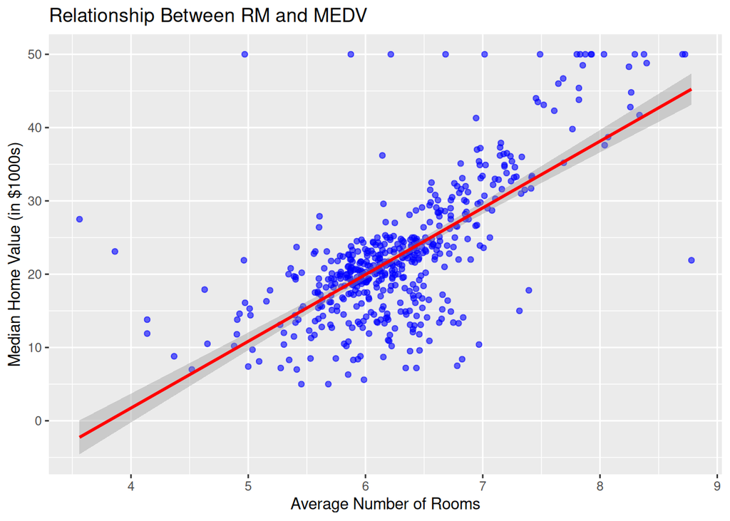

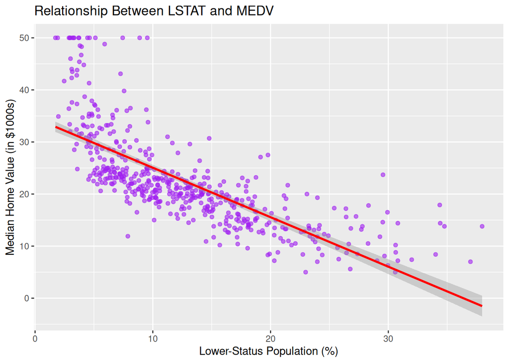

# 🏠 **7. Impact of Crime and Taxation on Home Prices**

## 🔍 **7.1 Distribution of `crim` and `tax`**

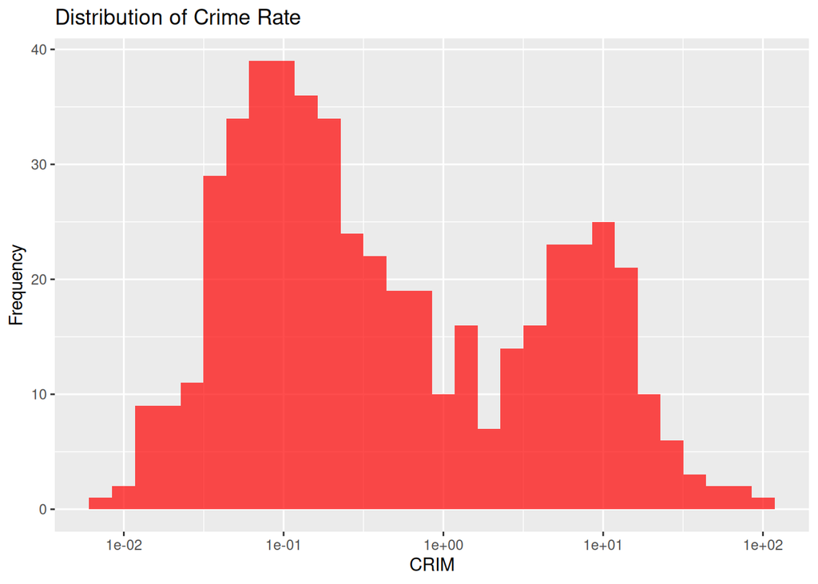

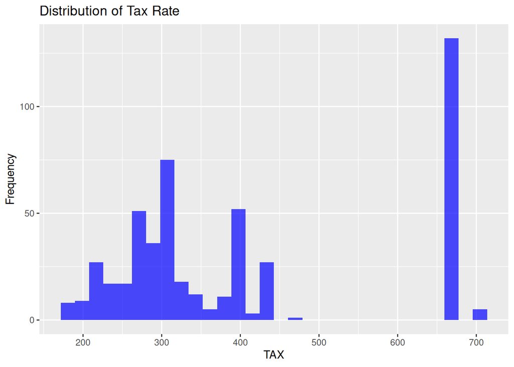

**Observations**:  
- **`crim` is highly skewed**: most neighborhoods have low crime rates, but some areas have extreme values.  
- **`tax` shows distinct peaks**, suggesting fixed tax rates in certain areas.

## **7.2 Relationship Between Crime Rate and Home Prices**

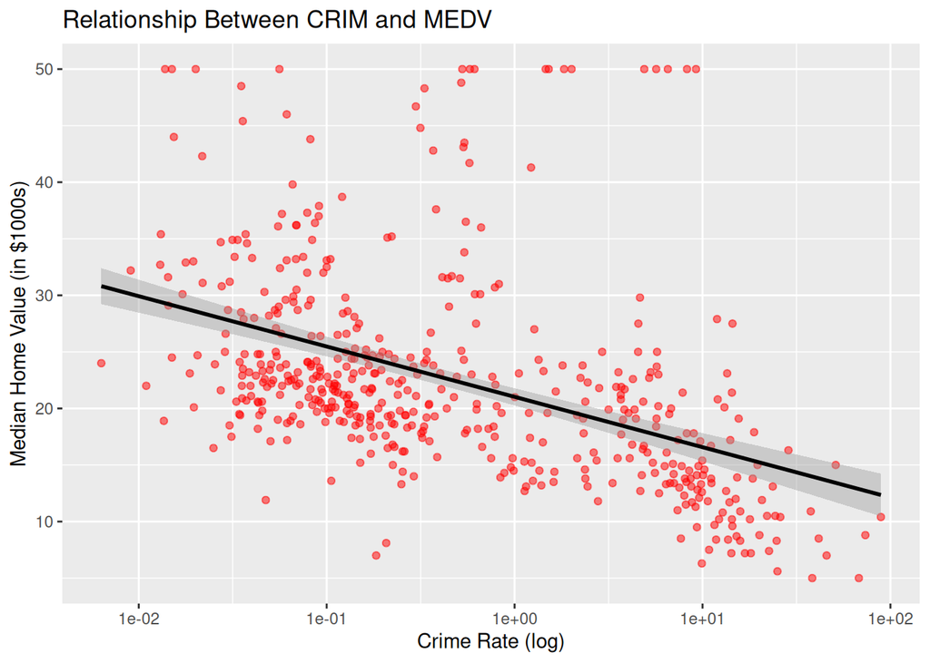

**Observation**: Home prices **decrease as crime rates increase**.

## **7.3 Relationship Between Taxation and Home Prices**

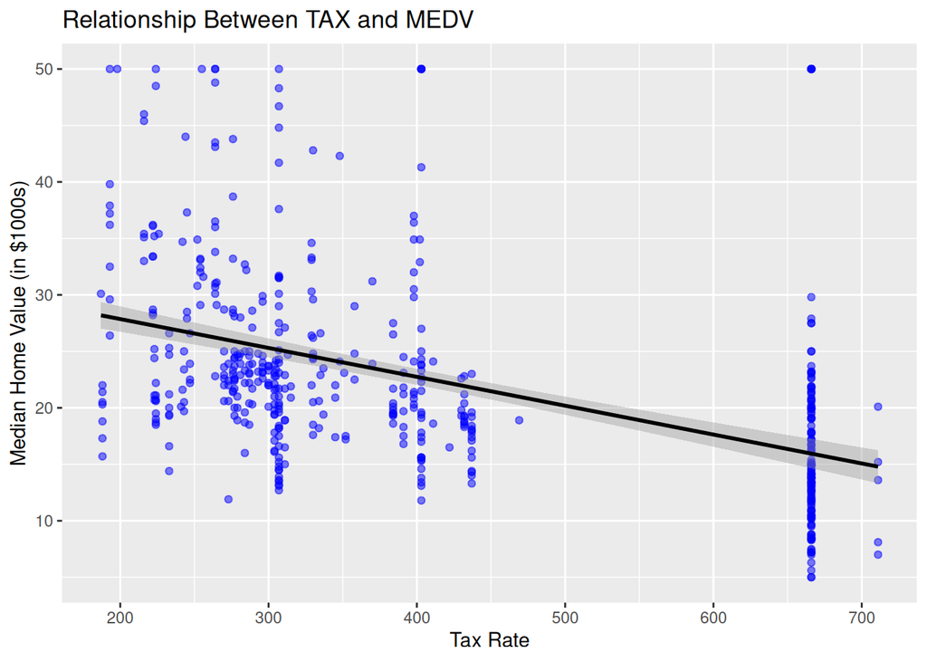

**Observation**: A **higher tax rate is associated with lower home prices**.

# **8. Multiple Regression Analysis**

```
##
## Call:
## lm(formula = medv ~ crim + tax, data = BostonHousing)
##
## Residuals:
##     Min      1Q  Median      3Q     Max
## -14.005  -4.929  -2.099   2.945  33.676
##
## Coefficients:
##              Estimate Std. Error t value Pr(>|t|)
## (Intercept) 31.379119   1.033523  30.361  < 2e-16 ***
## crim        -0.186617   0.051156  -3.648 0.000292 ***
## tax         -0.020018   0.002611  -7.667 9.15e-14 ***
## ---
## Signif. codes:  0 '***' 0.001 '**' 0.01 '*' 0.05 '.' 0.1 ' ' 1
##
## Residual standard error: 8.036 on 503 degrees of freedom
## Multiple R-squared:  0.2396, Adjusted R-squared:  0.2366
## F-statistic: 79.27 on 2 and 503 DF,  p-value: < 2.2e-16
```

**Results**:  
- **The coefficients for `crim` and `tax` are negative**, confirming their negative impact on `medv`.  
- **p-values < 0.05** indicate these effects are statistically significant.

# **Conclusion**